# Manual model development

## MVP

Question 1

```r
house_data <- read_csv("kc_house_data.csv")
```

[output not shown]

[output cut: 990 more lines]

Question 2

```r
alias(lm(price ~ ., data = house_data_clean))
```

```
Model :
price ~ bedrooms + bathrooms + sqft_living + sqft_lot + floors +
    waterfront + view + condition + grade + sqft_above + yr_built +
    yr_renovated + lat + long
```

Question 3

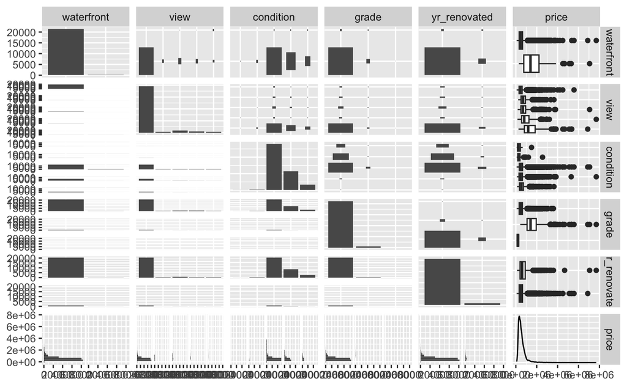

The numeric variables that are most strongly correlated with price are bathrooms (0.5), sqft living (0.7), and sqft above (0.6).

Categorical variables that seem of interest are waterfront, view, condition and grade.

Start with the most strongly correlated numeric variable, sqft living. Autoplot doesn’t look great. The model explains 0.4929 of the variance in house price.

```r
summary(mod_1)
```

```
Call:
lm(formula = price ~ sqft_living, data = house_data_clean)

Residuals:
     Min       1Q   Median       3Q      Max
-1476062  -147486   -24043   106182  4362067

Coefficients:
              Estimate Std. Error t value Pr(>|t|)
(Intercept) -43580.743   4402.690  -9.899   <2e-16 ***
sqft_living    280.624      1.936 144.920   <2e-16 ***
---
Signif. codes:  0 ‘***’ 0.001 ‘**’ 0.01 ‘*’ 0.05 ‘.’ 0.1 ‘ ’ 1

Residual standard error: 261500 on 21611 degrees of freedom
Multiple R-squared:  0.4929,    Adjusted R-squared:  0.4928
F-statistic: 2.1e+04 on 1 and 21611 DF,  p-value: < 2.2e-16
```

add sqft above to the model. It is significant and explains more variance.

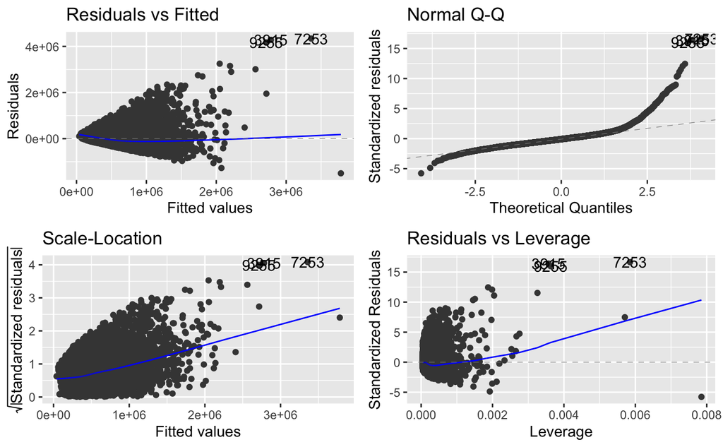

compare the two models

```r
anova(mod_1, mod_2)
```

```
Analysis of Variance Table

Model 1: price ~ sqft_living
Model 2: price ~ sqft_living + sqft_above
  Res.Df        RSS Df  Sum of Sq     F    Pr(>F)
1  21611 1.4773e+15
2  21610 1.4761e+15  1 1.2165e+12 17.81 2.451e-05 ***
---
Signif. codes:  0 ‘***’ 0.001 ‘**’ 0.01 ‘*’ 0.05 ‘.’ 0.1 ‘ ’ 1
```

My model including sqft above is better since the anova is significant.

Add bathrooms to the model.

```r
anova(mod_2, mod_3)
```

```
Analysis of Variance Table

Model 1: price ~ sqft_living + sqft_above
Model 2: price ~ sqft_living + sqft_above + bathrooms
  Res.Df        RSS Df  Sum of Sq      F Pr(>F)
1  21610 1.4761e+15
2  21609 1.4760e+15  1 9.0816e+10 1.3296 0.2489
```

Adding bathrooms to the model does not explain significantly more of the variance, according to the anvova.

Add categorical predictors to model 2.

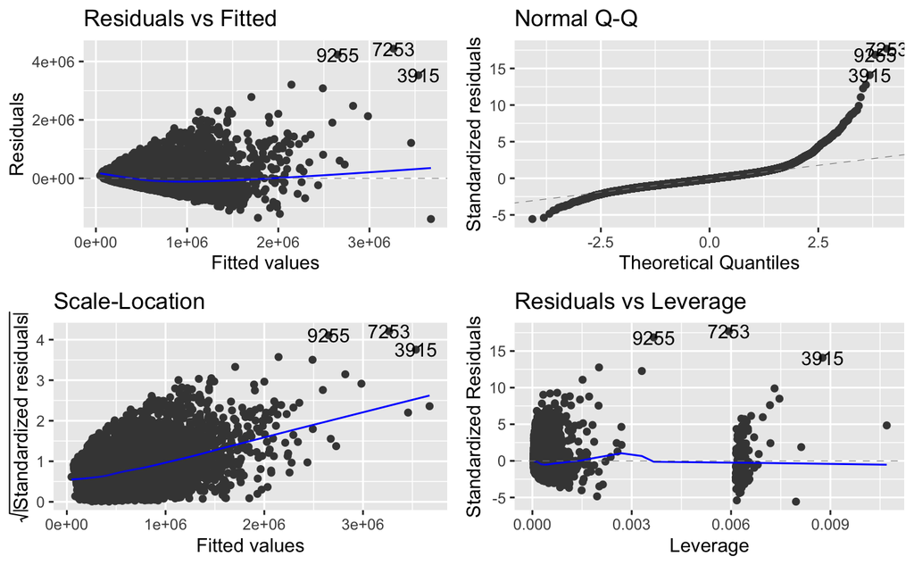

Waterfront is significant and more variance is explained.

add view to the model

```r
summary(mod_5)
```

```
Call:
lm(formula = price ~ sqft_living + sqft_above + waterfront +
    view, data = house_data_clean)

Residuals:
     Min       1Q   Median       3Q      Max
-1568343  -137748   -19552   104421  4445760

Coefficients:
              Estimate Std. Error t value Pr(>|t|)
(Intercept) -16981.180   4209.943  -4.034 5.51e-05 ***
sqft_living    245.579      3.958  62.045  < 2e-16 ***
sqft_above      13.133      4.266   3.078  0.00208 **
waterfront1 491476.188  23953.206  20.518  < 2e-16 ***
view1       171509.678  13680.761  12.537  < 2e-16 ***
view2       125814.980   8243.646  15.262  < 2e-16 ***
view3       199440.318  11292.694  17.661  < 2e-16 ***
view4       416598.861  17455.208  23.867  < 2e-16 ***
---
Signif. codes:  0 ‘***’ 0.001 ‘**’ 0.01 ‘*’ 0.05 ‘.’ 0.1 ‘ ’ 1

Residual standard error: 245500 on 21605 degrees of freedom
Multiple R-squared:  0.5531,    Adjusted R-squared:  0.553
F-statistic:  3820 on 7 and 21605 DF,  p-value: < 2.2e-16
```

Adding view explains more of the variance and the anova is significant.

Try other models. Model 6 explains more of the variance than model 2, so I will keep model 6 instead.

```r
summary(mod_6)
```

```
Call:
lm(formula = price ~ sqft_living + waterfront, data = house_data_clean)

Residuals:
     Min       1Q   Median       3Q      Max
-1376782  -142867   -21360   107201  4449253

Coefficients:
              Estimate Std. Error t value Pr(>|t|)
(Intercept) -32957.851   4242.971  -7.768 8.35e-15 ***
sqft_living    272.507      1.873 145.499  < 2e-16 ***
waterfront1 829983.104  19882.279  41.745  < 2e-16 ***
---
Signif. codes:  0 ‘***’ 0.001 ‘**’ 0.01 ‘*’ 0.05 ‘.’ 0.1 ‘ ’ 1

Residual standard error: 251500 on 21610 degrees of freedom
Multiple R-squared:  0.5307,    Adjusted R-squared:  0.5307
F-statistic: 1.222e+04 on 2 and 21610 DF,  p-value: < 2.2e-16
```

add view to the model

```r
summary(mod_7)
```

```
Call:
lm(formula = price ~ sqft_living + waterfront + view, data = house_data_clean)

Residuals:
     Min       1Q   Median       3Q      Max
-1585973  -138082   -18679   104209  4431910

Coefficients:
              Estimate Std. Error t value Pr(>|t|)
(Intercept) -15406.084   4179.551  -3.686 0.000228 ***
sqft_living    256.272      1.898 135.029  < 2e-16 ***
waterfront1 493320.942  23950.404  20.598  < 2e-16 ***
view1       167848.411  13631.634  12.313  < 2e-16 ***
view2       123240.747   8202.728  15.024  < 2e-16 ***
view3       195419.272  11219.088  17.418  < 2e-16 ***
view4       411456.526  17378.494  23.676  < 2e-16 ***
---
Signif. codes:  0 ‘***’ 0.001 ‘**’ 0.01 ‘*’ 0.05 ‘.’ 0.1 ‘ ’ 1

Residual standard error: 245500 on 21606 degrees of freedom
Multiple R-squared:  0.5529,    Adjusted R-squared:  0.5528
F-statistic:  4454 on 6 and 21606 DF,  p-value: < 2.2e-16
```

It is significant, but R square doesnt increase that much if I add view.

Try other categorical predictors after model 6.

condition was not significant.

```r
summary(mod_8)
```

```
Call:
lm(formula = price ~ sqft_living + waterfront + condition, data = house_data_clean)

Residuals:
     Min       1Q   Median       3Q      Max
-1381854  -141745   -21171   107759  4415317

Coefficients:
              Estimate Std. Error t value Pr(>|t|)
(Intercept) -26582.493  45692.037  -0.582    0.561
sqft_living    274.356      1.875 146.285   <2e-16 ***
waterfront1 821933.861  19768.105  41.579   <2e-16 ***
condition2  -37766.341  49458.409  -0.764    0.445
condition3  -26337.336  45721.331  -0.576    0.565
condition4    5280.843  45779.083   0.115    0.908
condition5   74339.508  46062.817   1.614    0.107
---
Signif. codes:  0 ‘***’ 0.001 ‘**’ 0.01 ‘*’ 0.05 ‘.’ 0.1 ‘ ’ 1

Residual standard error: 249900 on 21606 degrees of freedom
Multiple R-squared:  0.5366,    Adjusted R-squared:  0.5365
F-statistic:  4170 on 6 and 21606 DF,  p-value: < 2.2e-16
```

```r
summary(mod_9)
```

```
Call:
lm(formula = price ~ sqft_living + waterfront + grade, data = house_data_clean)

Residuals:
     Min       1Q   Median       3Q      Max
-1499082  -139146   -21724   102850  4313626

Coefficients:
                          Estimate Std. Error t value Pr(>|t|)
(Intercept)                27891.7     4362.9   6.393 1.66e-10 ***
sqft_living                  237.9        2.0 118.959  < 2e-16 ***
waterfront1               785416.8    19205.6  40.895  < 2e-16 ***
gradehigh quality         491552.1    12182.9  40.348  < 2e-16 ***
gradeunacceptable quality  38140.2   121324.7   0.314    0.753
---
Signif. codes:  0 ‘***’ 0.001 ‘**’ 0.01 ‘*’ 0.05 ‘.’ 0.1 ‘ ’ 1

Residual standard error: 242600 on 21608 degrees of freedom
Multiple R-squared:  0.5636,    Adjusted R-squared:  0.5635
F-statistic:  6976 on 4 and 21608 DF,  p-value: < 2.2e-16
```

R square increases a little if I add grade, possibly add.

check for all predictors

```r
summary(mod_all)
```

```
Call:
lm(formula = price ~ ., data = house_data_clean)

Residuals:
     Min       1Q   Median       3Q      Max
-1712287  -101292   -10024    76892  3892524

Coefficients:
                            Estimate Std. Error t value Pr(>|t|)
(Intercept)               -4.419e+07  1.576e+06 -28.043  < 2e-16 ***
bedrooms                  -3.564e+04  1.941e+03 -18.360  < 2e-16 ***
bathrooms                  5.103e+04  3.336e+03  15.296  < 2e-16 ***
sqft_living                1.876e+02  4.298e+00  43.640  < 2e-16 ***
sqft_lot                  -8.451e-02  3.570e-02  -2.367 0.017948 *
floors                     1.969e+04  3.666e+03   5.370 7.95e-08 ***
waterfront1                4.702e+05  2.022e+04  23.256  < 2e-16 ***
view1                      1.277e+05  1.156e+04  11.041  < 2e-16 ***
view2                      9.090e+04  6.991e+03  13.001  < 2e-16 ***
view3                      1.672e+05  9.590e+03  17.433  < 2e-16 ***
view4                      3.299e+05  1.476e+04  22.349  < 2e-16 ***
condition2                 5.541e+04  4.101e+04   1.351 0.176667
condition3                 6.686e+04  3.804e+04   1.758 0.078815 .
condition4                 1.040e+05  3.804e+04   2.734 0.006253 **
condition5                 1.394e+05  3.826e+04   3.644 0.000269 ***
gradehigh quality          4.133e+05  1.065e+04  38.816  < 2e-16 ***
gradeunacceptable quality  2.028e+05  1.040e+05   1.950 0.051208 .
sqft_above                 5.689e+01  4.384e+00  12.976  < 2e-16 ***
yr_built                  -1.539e+03  7.287e+01 -21.122  < 2e-16 ***
yr_renovatedTRUE           6.088e+04  7.509e+03   8.108 5.43e-16 ***
lat                        6.472e+05  1.060e+04  61.034  < 2e-16 ***
long                      -1.339e+05  1.188e+04 -11.270  < 2e-16 ***
---
Signif. codes:  0 ‘***’ 0.001 ‘**’ 0.01 ‘*’ 0.05 ‘.’ 0.1 ‘ ’ 1

Residual standard error: 206600 on 21591 degrees of freedom
Multiple R-squared:  0.6836,    Adjusted R-squared:  0.6833
F-statistic:  2221 on 21 and 21591 DF,  p-value: < 2.2e-16
```

All of them explains 68 % of the variance. Mod 6 explains 53 % of the variance. But mod 10, with view instead of waterfront explains more of the variance.

```r
summary(mod_10)
```

```
Call:
lm(formula = price ~ sqft_living + view, data = house_data_clean)

Residuals:
     Min       1Q   Median       3Q      Max
-1789849  -138864   -19086   103875  4417871

Coefficients:
              Estimate Std. Error t value Pr(>|t|)
(Intercept) -14446.102   4220.027  -3.423  0.00062 ***
sqft_living    255.791      1.916 133.485  < 2e-16 ***
view1       169608.795  13764.231  12.322  < 2e-16 ***
view2       127654.893   8279.853  15.418  < 2e-16 ***
view3       214288.421  11290.612  18.979  < 2e-16 ***
view4       620879.208  14231.252  43.628  < 2e-16 ***
---
Signif. codes:  0 ‘***’ 0.001 ‘**’ 0.01 ‘*’ 0.05 ‘.’ 0.1 ‘ ’ 1

Residual standard error: 247900 on 21607 degrees of freedom
Multiple R-squared:  0.5442,    Adjusted R-squared:  0.544
F-statistic:  5159 on 5 and 21607 DF,  p-value: < 2.2e-16
```

I’ll try adding waterfront.

```r
anova(mod_10, mod_11)
```

```
Analysis of Variance Table

Model 1: price ~ sqft_living + view
Model 2: price ~ sqft_living + view + waterfront
  Res.Df        RSS Df  Sum of Sq      F    Pr(>F)
1  21607 1.3278e+15
2  21606 1.3023e+15  1 2.5572e+13 424.26 < 2.2e-16 ***
---
Signif. codes:  0 ‘***’ 0.001 ‘**’ 0.01 ‘*’ 0.05 ‘.’ 0.1 ‘ ’ 1
```

The anova is significant, but not mych more of hte variance is explained. So I’ll stick to mod 10.

```r
anova(mod_11, mod_10)
```

```
Analysis of Variance Table

Model 1: price ~ sqft_living + view + waterfront
Model 2: price ~ sqft_living + view
  Res.Df        RSS Df   Sum of Sq      F    Pr(>F)
1  21606 1.3023e+15
2  21607 1.3278e+15 -1 -2.5572e+13 424.26 < 2.2e-16 ***
---
Signif. codes:  0 ‘***’ 0.001 ‘**’ 0.01 ‘*’ 0.05 ‘.’ 0.1 ‘ ’ 1
```

## Extensions

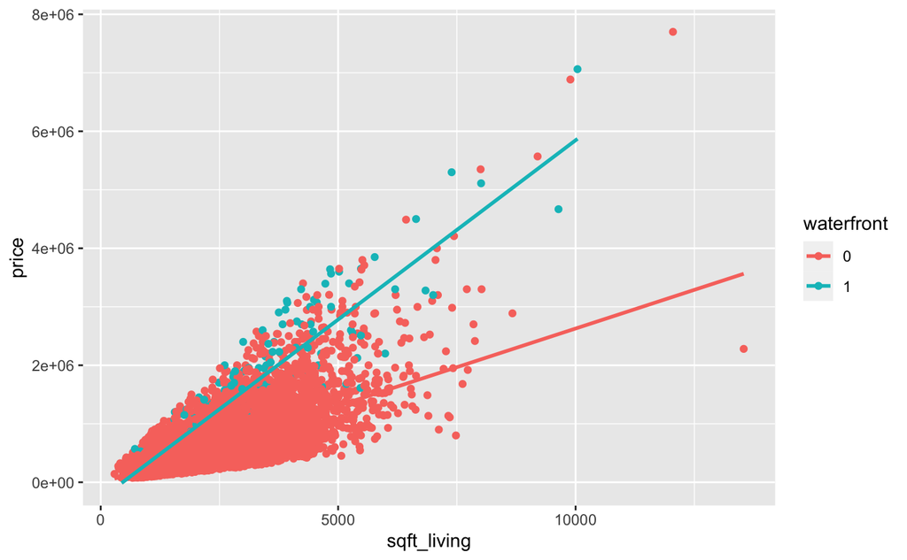

```r
calc.relimp(final_model, type = "lmg", rela = TRUE)
```

```
Response variable: price
Total response variance: 134782378397
Analysis based on 21613 observations

5 Regressors:
Some regressors combined in groups:
        Group  view : view1 view2 view3 view4

 Relative importance of 2 (groups of) regressors assessed:
 view sqft_living

Proportion of variance explained by model: 54.42%
Metrics are normalized to sum to 100% (rela=TRUE).

Relative importance metrics:

                  lmg
view        0.2017303
sqft_living 0.7982697

Average coefficients for different model sizes:

                 1group     2groups
sqft_living    280.6236    255.7914
view1       315716.6452 169608.7946
view2       295836.6957 127654.8934
view3       475401.0824 214288.4209
view4       967147.0461 620879.2085
```

sqft_living accounts for 80 % of the variance and view for 20 %.